# Static map projection comparison

## e06 — highlatitude_square

`north=65, east=10, south=55, west=-10` · center 60° · Geodesically near-square extent centered near 60N

Back to example grid ↑

### Figure e06 · m01 — Equal Earth

Equal Earth, centered on bbox

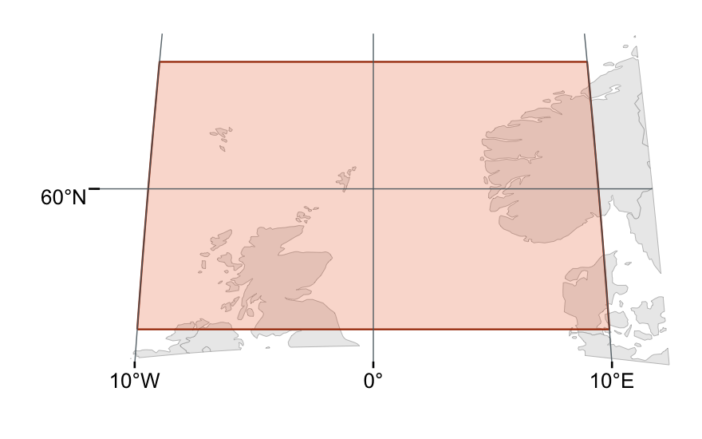

### Figure e06 · m02 — crsuggest top-ranked CRS

ED50 / TM 0 N (EPSG:23090)

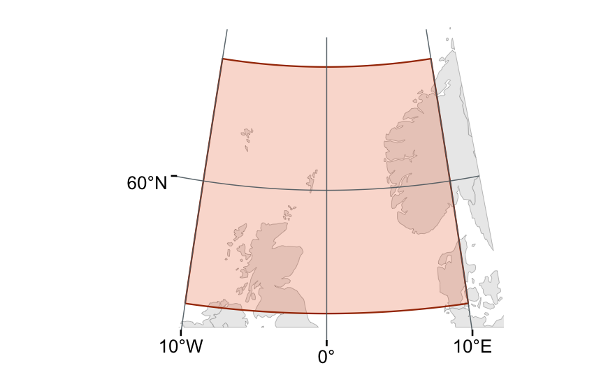

### Figure e06 · m03 — projWiz equal-area selection

projWiz::proj_region(property = 'Equal area'): +proj=laea +lon_0=0 +lat_0=60 +datum=WGS84 +units=m +no_defs

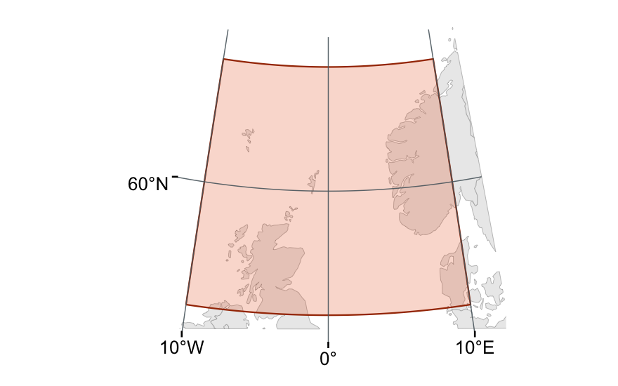

### Figure e06 · m04 — Custom extent-aware equal-area

Tall/square extent (width/height 1.00) → local LAEA

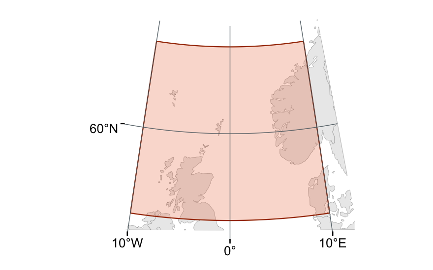

## e07 — highlatitude_tall

`north=75, east=15, south=55, west=-15` · center 65° · Tall extent centered near 65N

Back to example grid ↑

### Figure e07 · m01 — Equal Earth

Equal Earth, centered on bbox

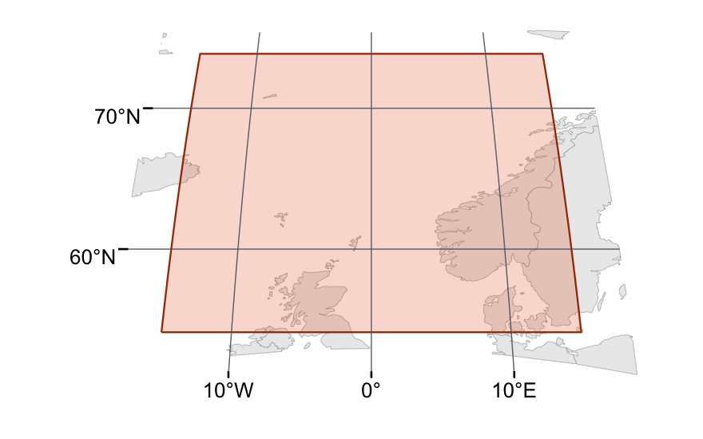

### Figure e07 · m02 — crsuggest top-ranked CRS

ED50 / UTM zone 31N (EPSG:23031)

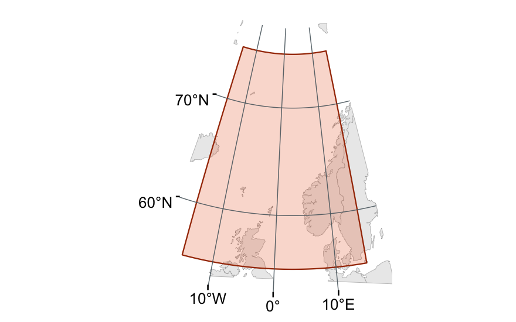

### Figure e07 · m03 — projWiz equal-area selection

projWiz::proj_region(property = 'Equal area'): +proj=laea +lon_0=0 +lat_0=65 +datum=WGS84 +units=m +no_defs

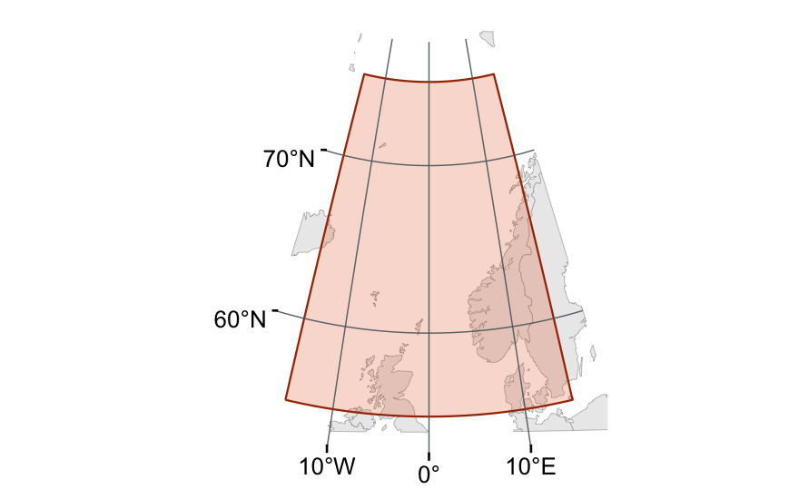

### Figure e07 · m04 — Custom extent-aware equal-area

Polar extent → LAEA centered at 90°

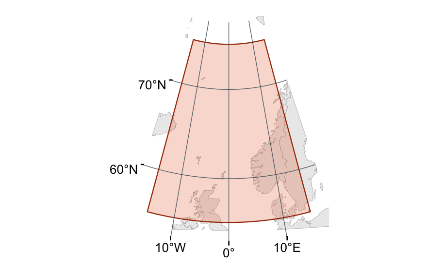

## e08 — near_pole_wide

`north=85, east=90, south=75, west=-90` · center 80° · Very wide extent near 80N; tests high-latitude projection choice

Back to example grid ↑

### Figure e08 · m02 — crsuggest top-ranked CRS

ETRS89-extended / LAEA Europe (EPSG:3035)

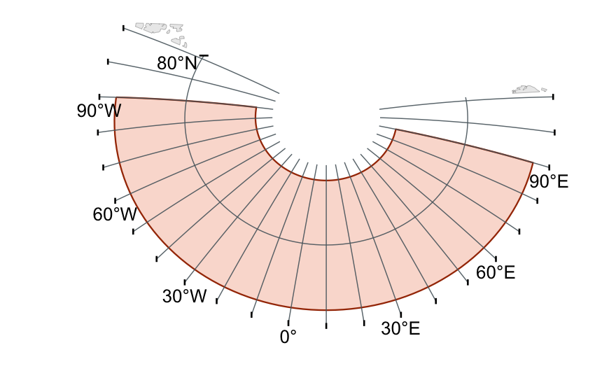

### Figure e08 · m04 — Custom extent-aware equal-area

Polar extent → LAEA centered at 90°

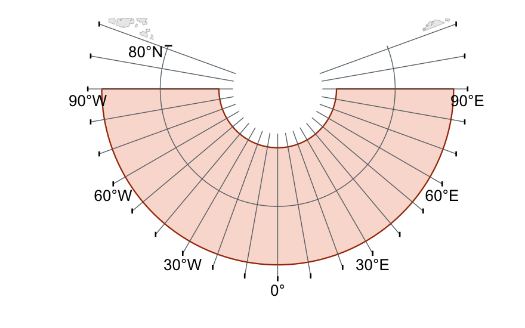

## e09 — north_polar_cap

`north=90, east=180, south=85, west=-180` · center 87.5° · Includes the North Pole and spans all longitudes

Back to example grid ↑

### Figure e09 · m01 — Equal Earth

Equal Earth, centered on bbox

[figure not shown]

### Figure e09 · m02 — crsuggest top-ranked CRS

WGS 84 / EPSG Russia Polar Stereographic (EPSG:5940)

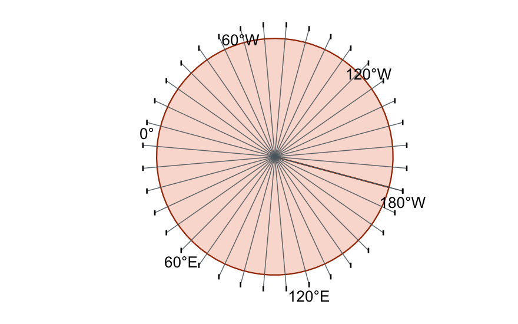

### Figure e09 · m03 — projWiz equal-area selection

projWiz::proj_region(property = 'Equal area'): +proj=laea +lon_0=0 +lat_0=87.5 +datum=WGS84 +units=m +no_defs

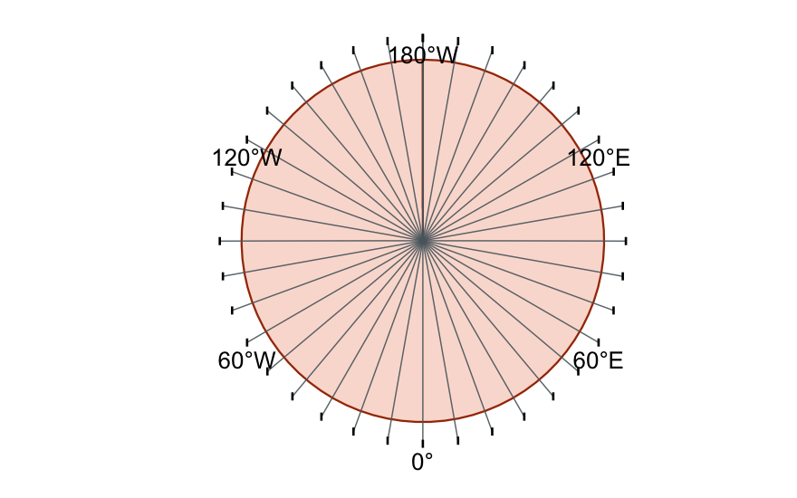

### Figure e09 · m04 — Custom extent-aware equal-area

Polar extent → LAEA centered at 90°

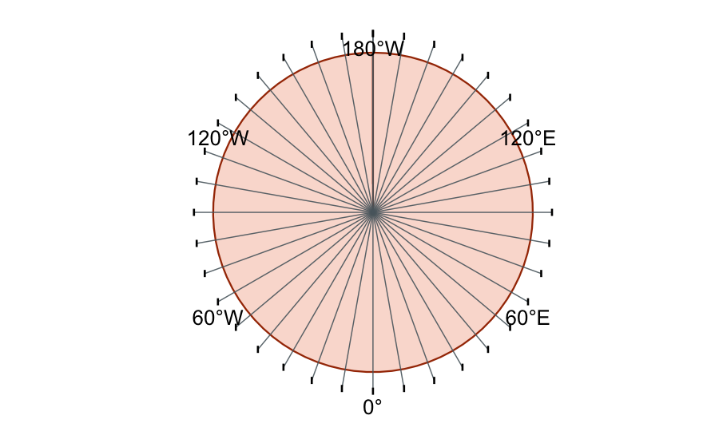

## e10 — antimeridian_small

`north=10, east=-170, south=-10, west=170` · center 0° · Crosses the antimeridian with a compact extent

Back to example grid ↑

### Figure e10 · m01 — Equal Earth

Equal Earth, centered on bbox

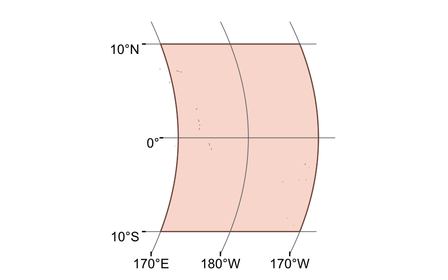

### Figure e10 · m02 — crsuggest top-ranked CRS

WGS 84 / PDC Mercator (EPSG:3832)

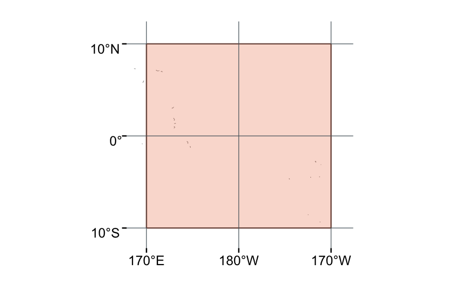

### Figure e10 · m03 — projWiz equal-area selection

projWiz::proj_region(property = 'Equal area'): +proj=laea +lon_0=180 +lat_0=0 +datum=WGS84 +units=m +no_defs

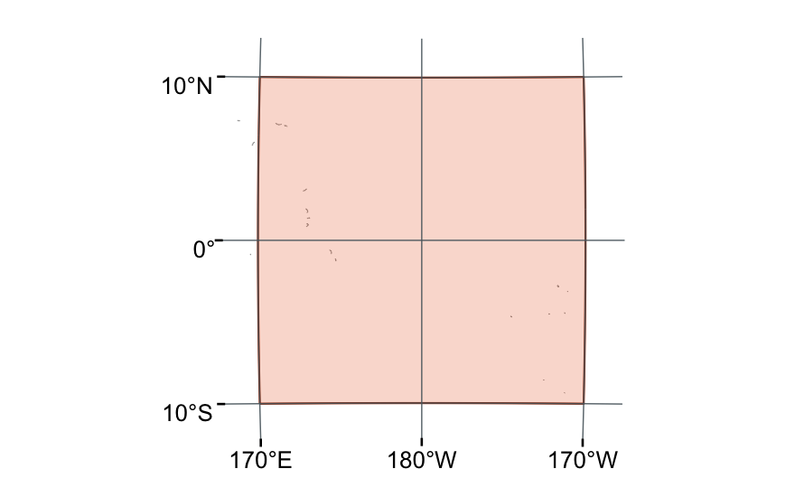

### Figure e10 · m04 — Custom extent-aware equal-area

Tall/square extent (width/height 1.00) → local LAEA

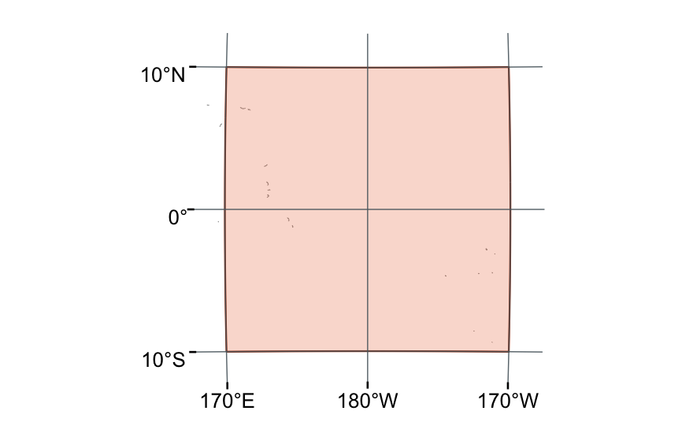

## e11 — antimeridian_regional

`north=70, east=-120, south=40, west=150` · center 55° · Crosses the antimeridian with a broad mid/high-latitude extent

Back to example grid ↑

### Figure e11 · m01 — Equal Earth

Equal Earth, centered on bbox

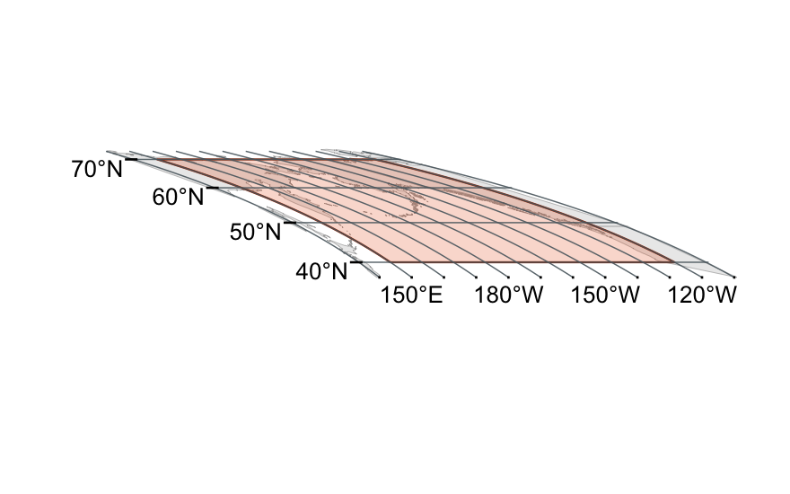

### Figure e11 · m02 — crsuggest top-ranked CRS

WGS 84 / EPSG Arctic Regional zone B5 (EPSG:5930)

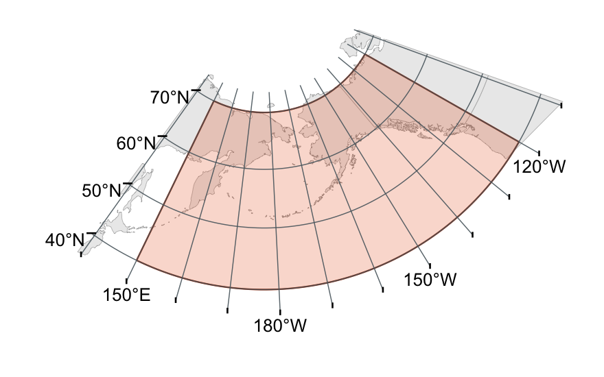

### Figure e11 · m03 — projWiz equal-area selection

projWiz::proj_region(property = 'Equal area'): +proj=aea +lon_0=195 +lat_1=45 +lat_2=65 +lat_0=55 +datum=WGS84 +units=m +no_defs

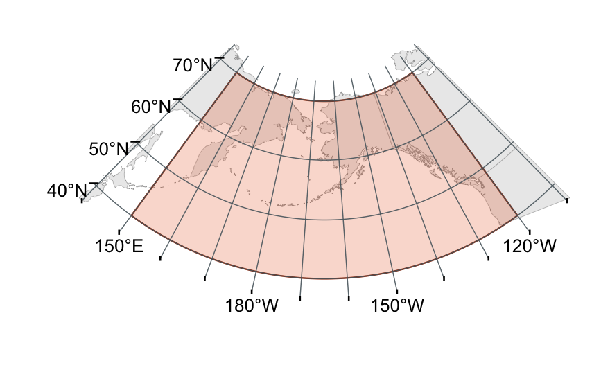

### Figure e11 · m04 — Custom extent-aware equal-area

Wide extent (width/height 1.72) → Albers equal-area conic

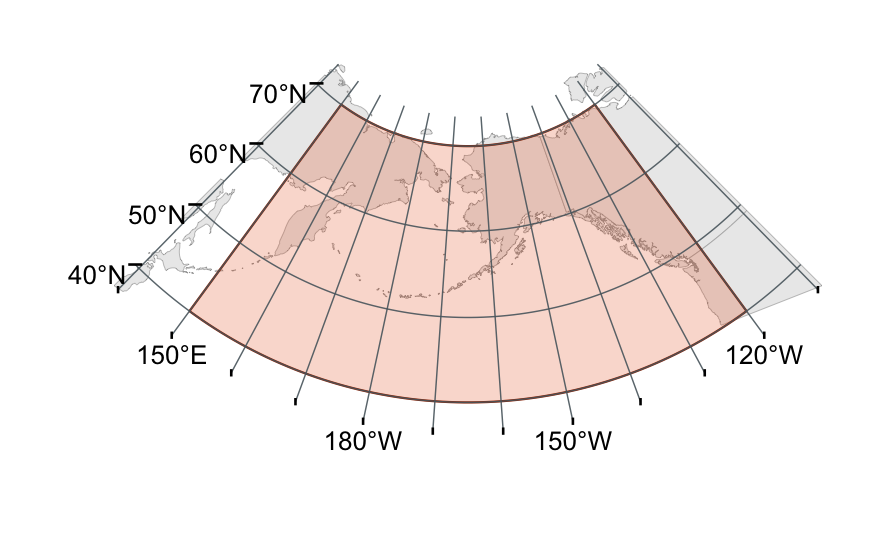

## e12 — issue_123_zenodo_extent

`north=52, east=20.2, south=49.9, west=5.1` · center 50.95° · Reported in issue #123: Zenodo 10.5281/zenodo.17791047 metadata bbox 52 20.2 49.9 5.1

Back to example grid ↑

### Figure e12 · m01 — Equal Earth

Equal Earth, centered on bbox

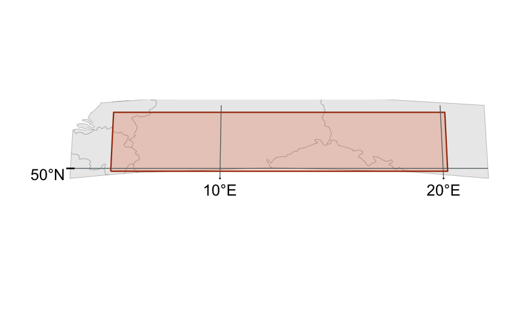

### Figure e12 · m02 — crsuggest top-ranked CRS

ETRS89 / LCC Germany (E-N) (EPSG:5243)

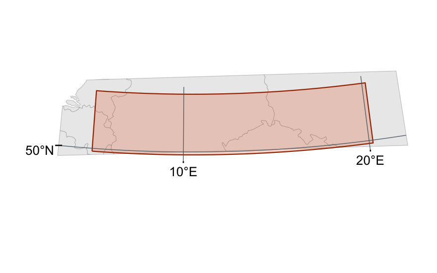

### Figure e12 · m03 — projWiz equal-area selection

projWiz::proj_region(property = 'Equal area'): +proj=aea +lon_0=12.65 +lat_1=50.25 +lat_2=51.65 +lat_0=50.95 +datum=WGS84 +units=m +no_defs

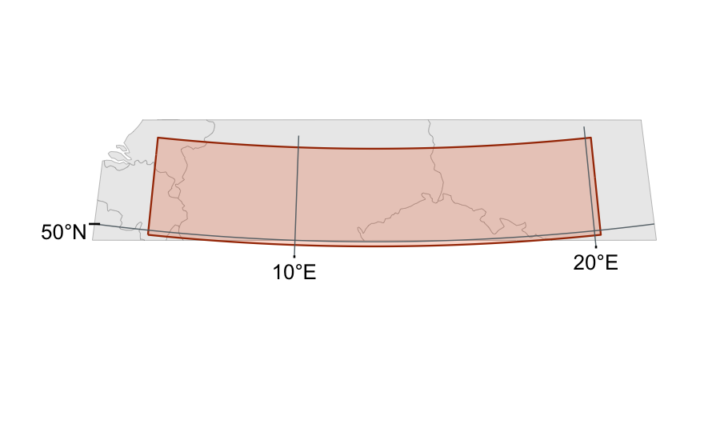

### Figure e12 · m04 — Custom extent-aware equal-area

Wide extent (width/height 4.53) → Albers equal-area conic

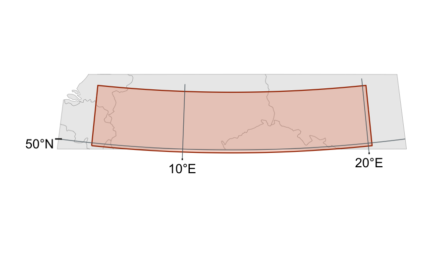